# Project Phase 4 – Hyperparameter Tuning

**Student Names:** Neil Mcguffin, William Makino , Roy Aggarwal and Gurpreet Bajwa **Program:** SAIT – Integrated Artificial Intelligence  
**Phase:** CRISP-DM Step 4 – Model Development  
Note: This notebook contains full EDA and feature selection, in addition to model training, evaluation, and tuning

## Introduction

This phase focuses on optimizing the various model hyperparameters to improve performance.

The goal is to develop an efficient prediction system that provides meaningful and actionable insights.

### Explanation

- **pandas & numpy** → used for data manipulation and numerical operations
- **matplotlib & seaborn** → used for data visualization
- **sklearn** → provides machine learning models and evaluation metrics
- **train_test_split** → divides dataset into training and testing sets
- **accuracy_score, confusion_matrix, classification_report** → evaluate model performance

```python
# import necessary libraries



import pandas as pd
import seaborn as sns
import matplotlib.pyplot as plt
import numpy as np
```

```python
import os, pathlib
print("CWD:", os.getcwd())
print("Notebook dir guess:", pathlib.Path().resolve())
```

```
CWD: c:\School\SAIT_AI\Term1\DATA440
Notebook dir guess: C:\School\SAIT_AI\Term1\DATA440
```

```python
# Load datase
df = pd.read_csv('credit_risk_individuals_10k.csv')

# Display first 5 rows
df.head()
```

|  | CustomerID | Age | EmploymentStatus | AnnualIncomeUSD | FICOScore | LatePayments12M | MaxDaysPastDue12M | MonthsSinceLastDelinquency | AccountTenureMonths | UtilizationRatePct | PaymentHistoryScore | DefaultNext12M |
| --- | --- | --- | --- | --- | --- | --- | --- | --- | --- | --- | --- | --- |
| 0 | IND0000001 | 48 | Employed_FT | 76132 | 682 | 0 | 0 | 89 | 89 | 43.7 | 93 | 0 |
| 1 | IND0000002 | 39 | Employed_FT | 48722 | 595 | 0 | 0 | 24 | 24 | 42.9 | 74 | 0 |
| 2 | IND0000003 | 50 | Employed_FT | 116696 | 693 | 0 | 0 | 94 | 94 | 22.7 | 94 | 0 |
| 3 | IND0000004 | 62 | Employed_FT | 45337 | 474 | 9 | 35 | 0 | 87 | 48.4 | 37 | 1 |
| 4 | IND0000005 | 38 | Self_Employed | 30848 | 669 | 0 | 0 | 84 | 84 | 18.0 | 87 | 0 |

### Explanation

The dataset is loaded into a pandas DataFrame.  
This allows structured data manipulation and inspection.

```python
df.info()
df.describe()
```

```
<class 'pandas.core.frame.DataFrame'>
RangeIndex: 10000 entries, 0 to 9999
Data columns (total 12 columns):
 #   Column                      Non-Null Count  Dtype
---  ------                      --------------  -----
 0   CustomerID                  10000 non-null  object
 1   Age                         10000 non-null  int64
 2   EmploymentStatus            10000 non-null  object
 3   AnnualIncomeUSD             10000 non-null  int64
 4   FICOScore                   10000 non-null  int64
 5   LatePayments12M             10000 non-null  int64
 6   MaxDaysPastDue12M           10000 non-null  int64
 7   MonthsSinceLastDelinquency  10000 non-null  int64
 8   AccountTenureMonths         10000 non-null  int64
 9   UtilizationRatePct          10000 non-null  float64
 10  PaymentHistoryScore         10000 non-null  int64
 11  DefaultNext12M              10000 non-null  int64
dtypes: float64(1), int64(9), object(2)
memory usage: 937.6+ KB
```

|  | Age | AnnualIncomeUSD | FICOScore | LatePayments12M | MaxDaysPastDue12M | MonthsSinceLastDelinquency | AccountTenureMonths | UtilizationRatePct | PaymentHistoryScore | DefaultNext12M |
| --- | --- | --- | --- | --- | --- | --- | --- | --- | --- | --- |
| count | 10000.000000 | 10000.000000 | 10000.000000 | 10000.000000 | 10000.000000 | 10000.000000 | 10000.000000 | 10000.000000 | 10000.000000 | 10000.000000 |
| mean | 41.268000 | 60245.414400 | 677.416600 | 0.876600 | 11.558500 | 73.481300 | 86.403600 | 31.097560 | 82.872700 | 0.112200 |
| std | 13.414387 | 40499.491851 | 89.245402 | 2.305191 | 32.374898 | 64.706848 | 62.940973 | 17.483365 | 19.336874 | 0.315628 |
| min | 18.000000 | 5000.000000 | 300.000000 | 0.000000 | 0.000000 | 0.000000 | 1.000000 | 0.000000 | 0.000000 | 0.000000 |
| 25% | 32.000000 | 31482.500000 | 631.000000 | 0.000000 | 0.000000 | 20.000000 | 36.000000 | 18.400000 | 75.000000 | 0.000000 |
| 50% | 41.000000 | 52501.500000 | 689.000000 | 0.000000 | 0.000000 | 58.000000 | 74.000000 | 31.000000 | 88.000000 | 0.000000 |
| 75% | 50.000000 | 79795.500000 | 738.000000 | 0.000000 | 0.000000 | 114.000000 | 126.000000 | 42.900000 | 99.000000 | 0.000000 |
| max | 85.000000 | 250000.000000 | 850.000000 | 12.000000 | 180.000000 | 351.000000 | 351.000000 | 97.600000 | 100.000000 | 1.000000 |

```python
# set DefaultNext12M to variable 'target' to save some typing

target = "DefaultNext12M"
```

```python
# Change EmploymentStatus to categorical type

df['EmploymentStatus'] = df['EmploymentStatus'].astype('category')
```

```python
# Check for any null values

df.isna().sum()
```

```
CustomerID                    0
Age                           0
EmploymentStatus              0
AnnualIncomeUSD               0
FICOScore                     0
LatePayments12M               0
MaxDaysPastDue12M             0
MonthsSinceLastDelinquency    0
AccountTenureMonths           0
UtilizationRatePct            0
PaymentHistoryScore           0
DefaultNext12M                0
dtype: int64
```

```python
# check for duplicate values

df.duplicated().sum()
```

```
np.int64(0)
```

```python
income = 'AnnualIncomeUSD'
fico = 'FICOScore'
late = 'LatePayments12M'
pastdue = 'MaxDaysPastDue12M'
delinquent = 'MonthsSinceLastDeliquency'
tenure = 'AccountTenureMonths'
history = 'PaymentHistoryScore'
totalcredit = 'UtilizationRatePct'
age = 'Age'
work = 'EmploymentStatus'
```

```python
# Get a count of our target variable; default (1) vs. non-default (0)

counts = df['DefaultNext12M'].value_counts().sort_index()
print(counts)
```

```
DefaultNext12M
0    8878
1    1122
Name: count, dtype: int64
```

```python
# Better plot style
sns.set(style="whitegrid")
```

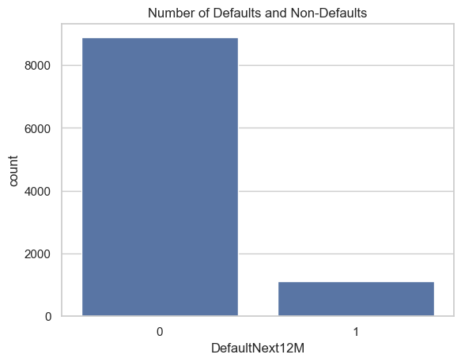

```python
# Create a count plot to visualize the number of defaults vs non-defaults
sns.countplot(data=df, x=target)
plt.title('Number of Defaults and Non-Defaults')
plt.show()
```

We have some skew in the data, but the number of defaults is greater than 10% of the total data set, so we likely won't require any modifications to address the skew. We will need to be cautious about train/test splitting to ensure a proportional number of defaults are represented to train and test against.

## Crosstab check and Countplots of Categorical Features

```python
# Crosstabe of Employment Status and Default (Employment Status is our only categorical feature)

pd.crosstab(
    df["EmploymentStatus"],
    df["DefaultNext12M"],
    normalize="index"
)
```

| DefaultNext12M EmploymentStatus | 0 | 1 |
| --- | --- | --- |
| Contract | 0.888441 | 0.111559 |
| Employed_FT | 0.895758 | 0.104242 |
| Employed_PT | 0.878553 | 0.121447 |
| Retired | 0.909722 | 0.090278 |
| Self_Employed | 0.905618 | 0.094382 |
| Student | 0.832998 | 0.167002 |
| Unemployed | 0.835821 | 0.164179 |

```python
# Print the defaults as a percentage of employment type

default_rate = df.groupby("EmploymentStatus")["DefaultNext12M"].mean().sort_values(ascending=False)

print(default_rate)
```

```
EmploymentStatus
Student          0.167002
Unemployed       0.164179
Employed_PT      0.121447
Contract         0.111559
Employed_FT      0.104242
Self_Employed    0.094382
Retired          0.090278
Name: DefaultNext12M, dtype: float64
```

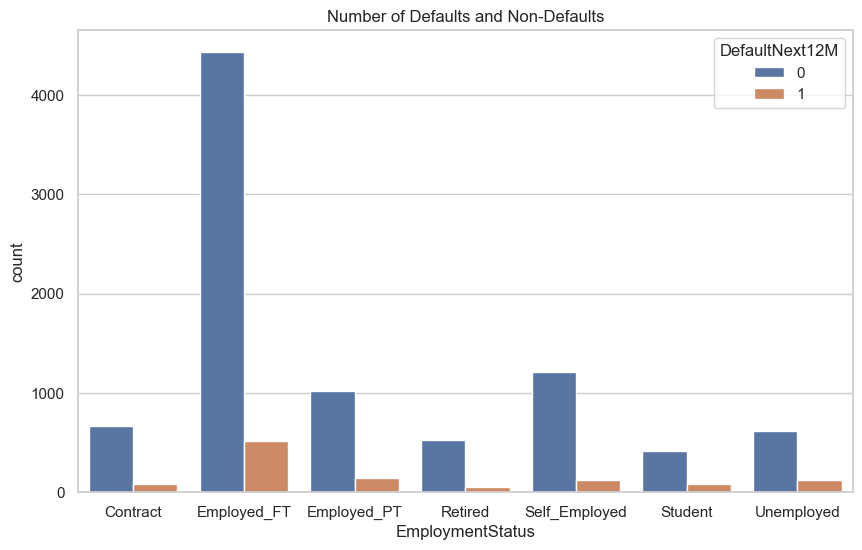

```python
# Create a count plot to visualize the number of defaults vs non-defaults

plt.figure(figsize=(10,6))
sns.countplot(data=df, x=work, hue=target)
plt.title('Number of Defaults and Non-Defaults')
plt.show()
```

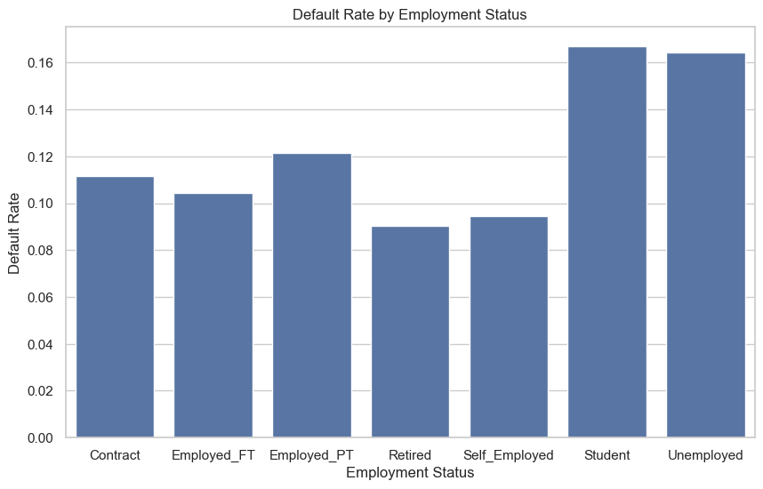

```python
# visualize default rate as a percentage by employment status

default_rate = df.groupby("EmploymentStatus")["DefaultNext12M"].mean()

plt.figure(figsize=(10,6))
sns.barplot(x=default_rate.index, y=default_rate.values)

plt.ylabel("Default Rate")
plt.xlabel("Employment Status")
plt.title("Default Rate by Employment Status")
plt.show()
```

Student and Unemployed Employment Status have a moderately higher ratio of default compared to the other types of employment

## KDE Plots and Feature Impact on Default

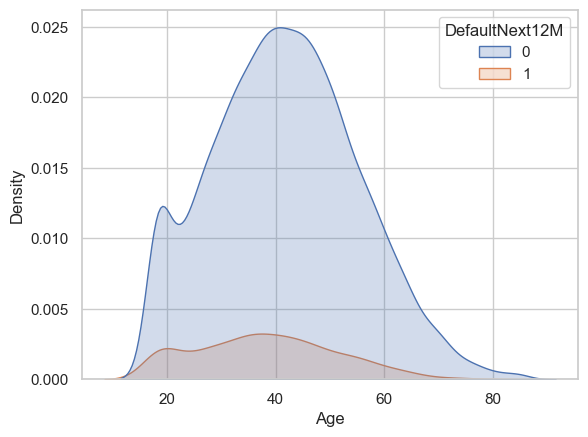

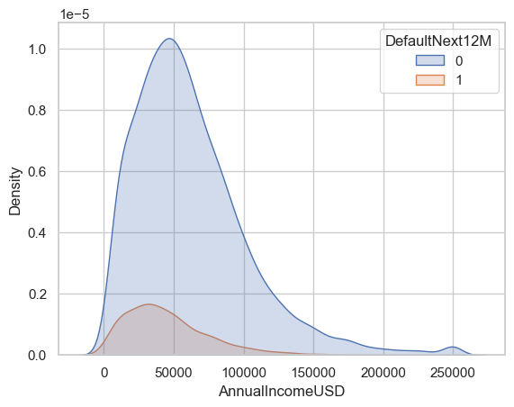

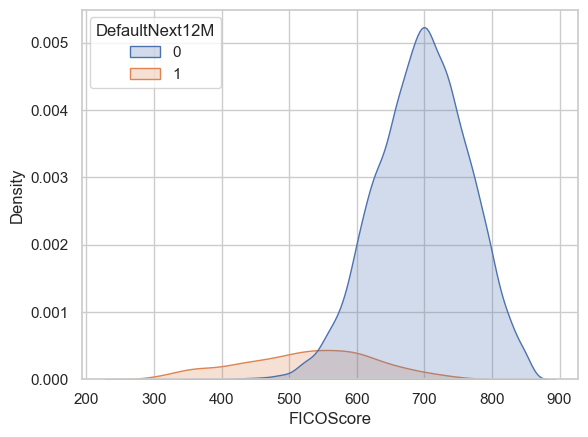

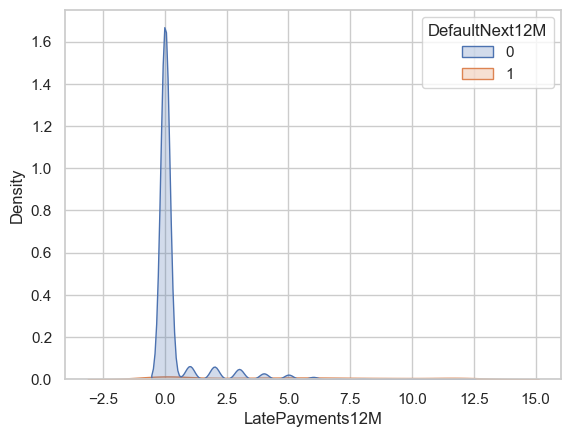

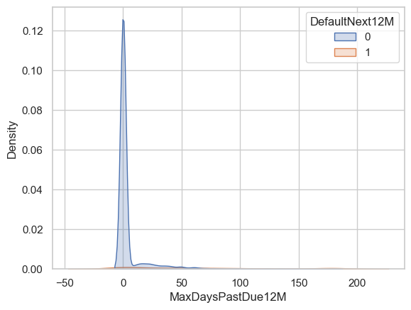

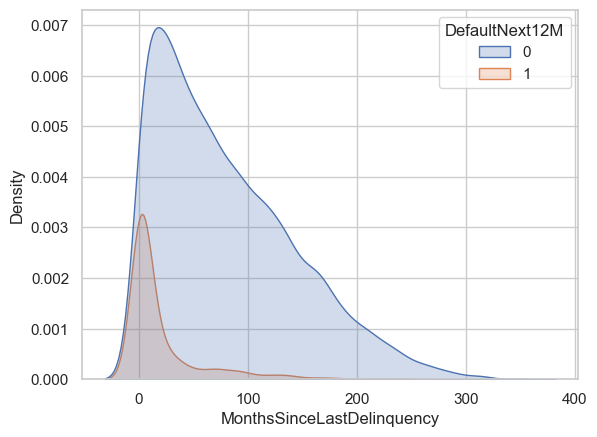

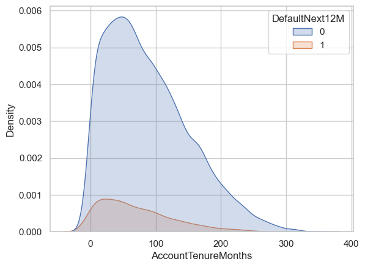

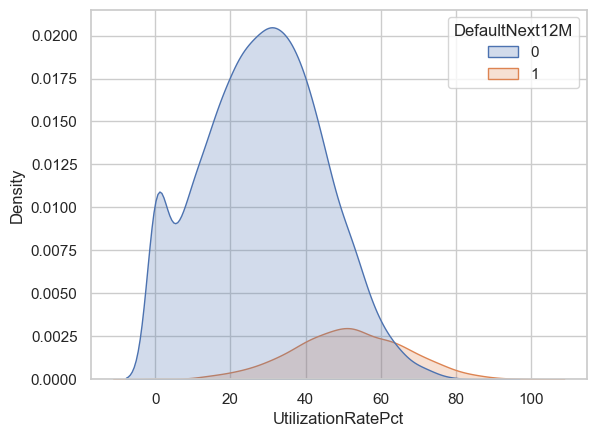

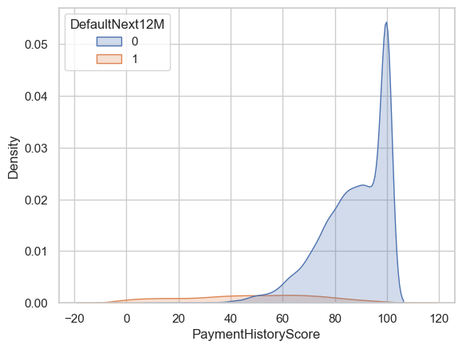

```python
# plotting each of the numeric values in kde plots with Default

num_col = df.select_dtypes("number").columns.drop(target)

for col in num_col:
    sns.kdeplot(data = df, x = col, hue = target, fill=True)
    plt.show()
```

Credit history, payment truancy, and FICO Score (which encapsulates some of those behaviors) appear to have a greater influence of probability of default than some other metrics. Age plays a small role, and lower income earners appear to default more frequently than higher income earners.

## Box Plot Analysis

In credit risk analysis, box plots help identify unusual borrower characteristics such as extremely low credit scores or unusually high credit utilization, which may signal higher financial risk.

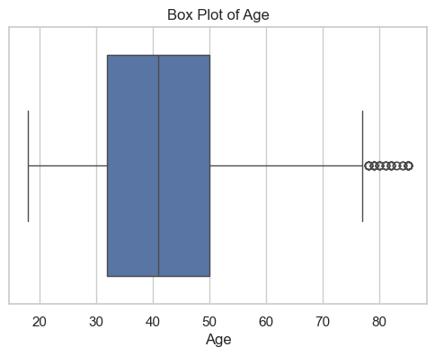

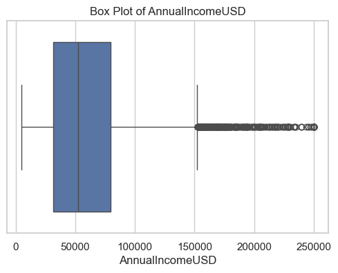

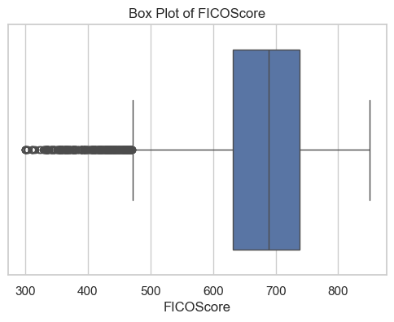

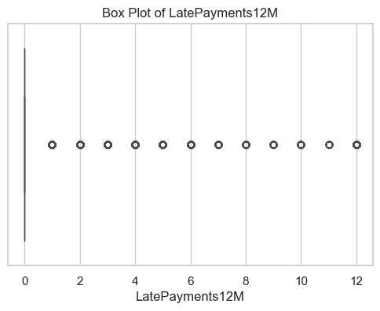

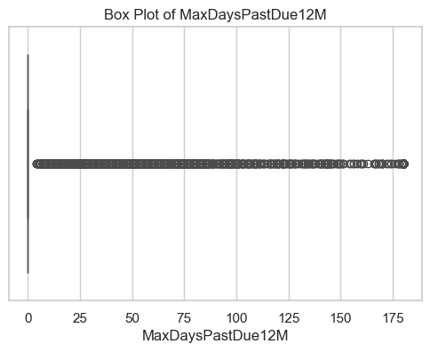

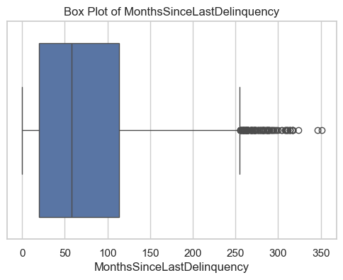

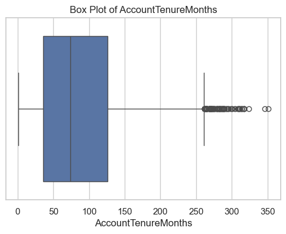

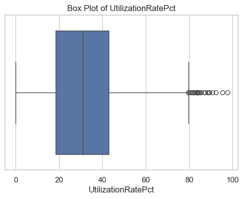

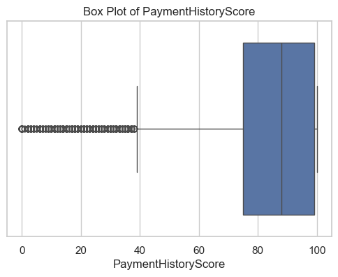

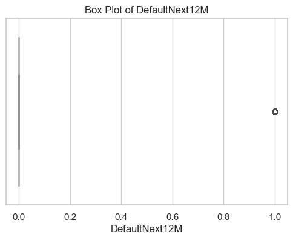

```python
# Generate Boxplots

numeric_cols = df.select_dtypes(include=['int64','float64']).columns

for col in numeric_cols:
    plt.figure(figsize=(6,4))
    sns.boxplot(x=df[col])
    plt.title(f"Box Plot of {col}")
    plt.show()
```

## Summary of Box Plot Analysis

The box plots overview helps highlight differences in borrower characteristics such as credit scores, credit utilization, income, and other financial indicators. While some of the plots are less useful for certain features, it is clear some borrowers have unusually high or low values compared to the majority of the dataset, which may be important when assessing financial behavior and credit risk.

## Heatmap Assessment

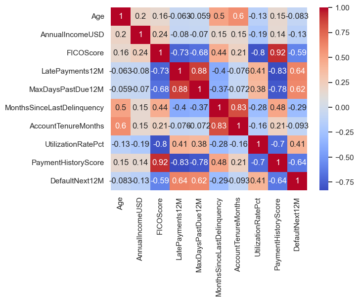

```python
# heatmap of numeric features
sns.heatmap(df.corr(numeric_only=True), annot=True, cmap='coolwarm')
plt.show()
```

```python
# Calculating the Pearson Correlation Matrix

corr_with_target = df.corr(numeric_only=True)["DefaultNext12M"]
corr_with_target = corr_with_target.drop("DefaultNext12M")
corr_with_target = corr_with_target.sort_values(key=abs, ascending=False)

corr_with_target
```

```
PaymentHistoryScore          -0.641150
LatePayments12M               0.636617
MaxDaysPastDue12M             0.615532
FICOScore                    -0.591377
UtilizationRatePct            0.412209
MonthsSinceLastDelinquency   -0.291980
AnnualIncomeUSD              -0.130699
AccountTenureMonths          -0.093440
Age                          -0.083469
Name: DefaultNext12M, dtype: float64
```

The following table ranks predictors by the absolute strength of their Pearson correlation with the target variable DefaultNext12M

```python
corr_with_target.to_frame("Correlation with DefaultNext12M")
```

|  | Correlation with DefaultNext12M |
| --- | --- |
| PaymentHistoryScore | -0.641150 |
| LatePayments12M | 0.636617 |
| MaxDaysPastDue12M | 0.615532 |
| FICOScore | -0.591377 |
| UtilizationRatePct | 0.412209 |
| MonthsSinceLastDelinquency | -0.291980 |
| AnnualIncomeUSD | -0.130699 |
| AccountTenureMonths | -0.093440 |
| Age | -0.083469 |

The correlation heatmap reveals several strong relationships among engineered credit features. FICOScore and PaymentHistoryScore show a very strong correlation (0.92), suggesting they capture largely overlapping information about borrower creditworthiness. To reduce redundancy, PaymentHistoryScore will likely be removed while retaining FICOScore as the primary credit quality indicator.

UtilizationRatePct is also strongly negatively correlated with FICOScore (-0.80), indicating that credit utilization is likely partially captured within the FICO score. The impact of retaining or removing this feature will be evaluated during model development.

LatePayments12M and MaxDaysPastDue12M exhibit a strong positive correlation (0.88), reflecting the relationship between delinquency frequency and severity. These variables may require further consideration during feature selection or potential feature engineering.

MonthsSinceLastDelinquency and AccountTenureMonths show a strong positive relationship (0.83). Since MonthsSinceLastDelinquency has a stronger relationship with DefaultNext12M, AccountTenureMonths may be removed during modeling to reduce redundancy.

# Summary

| Column 1 | Column 2 |
| --- | --- |
| Cusomter Id | drop |
| Age | keep |
| EmploymentStatus | keep |
| AnnualIncomeUSD | keep |
| FICOScore | keep |
| LatePayments12M | keep |
| MaxDaysPastDue12M | drop |
| MonthsSinceLastDelinquency | keep |
| AccountTenureMonths | drop |
| UtilizationRatePct | drop? |
| PaymentHistoryScore | drop |

[output not shown]

## Pearson correlation

The Pearson correlation coefficient measures the strength and direction of a linear relationship between two variables. It ranges from -1 to 1, where values near 1 indicate strong positive relationships, values near -1 indicate strong negative relationships, and values near 0 indicate little or no linear relationship. In this dataset, Pearson correlation is used to measure the relationship between each feature and the target variable DefaultNext12M.

## Attribute importance

Based on the correlation heatmap, boxplots, and kde plots, the most important predictors of default appear to be payment behavior variables such as LatePayments12M and MaxDaysPastDue12M, as well as credit score indicators such as FICOScore. These features show the strongest correlations with DefaultNext12M, suggesting they contain the most predictive information. Demographic information appear less important, but still contain useful information to help determine the likelihood of default.

## k-fold cross-validation

k-fold cross-validation is a model validation technique where the dataset is divided into k subsets (folds). The model is trained k times, each time using k-1 folds for training and one fold for validation. This process ensures that each observation is used for both training and validation and provides a more reliable estimate of model performance.

## Train/test split

A typical machine learning workflow splits the dataset into training and test sets. The training dataset (70–80%) is used to train the model, while the test dataset (20–30%) is used to evaluate model performance on unseen data. This separation helps prevent overfitting and ensures the model generalizes well to new data.

# Prepare for Training

### Explanation

- Missing values are removed to ensure clean data
- X represents independent variables (features)
- y represents dependent variable (target)
- Data is split:
  - 80% → training
  - 20% → testing

This ensures the model is evaluated on unseen data.

```python
# Drop Customer Id (just a label), drop MaxDaysPastDue12M (overlaps with LatePayments12M),
# drop AccountTenure, drop UtilizationRtPct, drop PaymentHistoryScore - all factored into FICO
# or institution specific

X = df.drop(columns = ["CustomerID","MaxDaysPastDue12M","AccountTenureMonths",
                        "UtilizationRatePct","PaymentHistoryScore", "DefaultNext12M"])
y = df["DefaultNext12M"]
```

```python
X.info()
```

```
<class 'pandas.core.frame.DataFrame'>
RangeIndex: 10000 entries, 0 to 9999
Data columns (total 6 columns):
 #   Column                      Non-Null Count  Dtype
---  ------                      --------------  -----
 0   Age                         10000 non-null  int64
 1   EmploymentStatus            10000 non-null  category
 2   AnnualIncomeUSD             10000 non-null  int64
 3   FICOScore                   10000 non-null  int64
 4   LatePayments12M             10000 non-null  int64
 5   MonthsSinceLastDelinquency  10000 non-null  int64
dtypes: category(1), int64(5)
memory usage: 400.9 KB
```

```python
# Get numeric, categorical, and binary column names for column selection in future steps
# Note that binary columns will be converted to int data type here but kept sepearate from numeric columns
# since they don't require imputation and scaling.

num_cols = ['age', 'AnnualIncomeUSD', 'FICOScore', 'LatePayments12M', 'MonthsSinceLastDelinquency']
cat_cols = ['EmploymentStatus']
bin_cols = ['DefaultNext12M']

num_cols = X.select_dtypes("number").columns
cat_cols = X.select_dtypes("category").columns
bin_cols = X.select_dtypes("bool").columns

X[bin_cols] = X[bin_cols].astype("int")
```

```python
# Split the dataset into training and testing sets (80% train, 20% test)
# This must be done after data cleaning but before any encoding or scaling
# to avoid data leakage
from sklearn.model_selection import train_test_split

X_train, X_test, y_train, y_test = train_test_split(
    X, y,
    test_size=0.2,
    random_state=42)
```

```python
# Numeric pipeline for imputation (filling missing values) and scaling
from sklearn.pipeline import Pipeline
from sklearn.impute import SimpleImputer
from sklearn.preprocessing import StandardScaler

# Pipeline determines the order of transformations to be applied to the
# numeric features
num_pipeline = Pipeline([
    ("imputer", SimpleImputer(strategy = "median")),
    ("scaler", StandardScaler())
])
```

```python
# Categorical pipeline for imputation (filling missing values) and encoding
from sklearn.preprocessing import OneHotEncoder

# Pipeline determines the order of transformations to be applied to the
# categorical features
cat_pipeline = Pipeline([
    ("imputer", SimpleImputer(strategy = "most_frequent")),
    ("encoder", OneHotEncoder(handle_unknown = "ignore"))
])
```

```python
# Combine numeric and categorical pipelines into a single preprocessor
# using ColumnTransformer
from sklearn.compose import ColumnTransformer

preprocessor = ColumnTransformer([
    ("num", num_pipeline, num_cols),
    ("bin", "passthrough", bin_cols),
    ("cat", cat_pipeline, cat_cols)
])
```

### Logistic Regression

Predicts probability using sigmoid function.

Simple and interpretable  
Good baseline model

### Default Hyperparameters – Logistic Regression

**penalty = 'l2'** Adds regularization to prevent overfitting by penalizing large coefficients

**C = 1.0** Controls strength of regularization (lower = stronger regularization)

**solver = 'lbfgs'** Optimization algorithm used to find the best model parameters

**max_iter = 1000** Maximum number of iterations for the solver to converge

**fit_intercept = True** Adds an intercept (bias term) to improve model flexibility

```python
# Create a pipeline that combines the preprocessor with a logistic regression model
from sklearn.linear_model import LogisticRegression

# Create a pipeline that combines the preprocessor with the
# logistic regression model
log_model = Pipeline([
    ("preprocess", preprocessor),
    ("model", LogisticRegression(max_iter=1000))
])

# Fit the model on the training data
log_model.fit(X_train, y_train)

# Make predictions on the test set
log_preds = log_model.predict(X_test)
```

### Decision Tree

Splits data based on rules like a flowchart. Handles non-linear data  
Easy to interpret

### Default Hyperparameters – Decision Tree

**criterion = 'gini'** Measures impurity to decide how splits are made

**splitter = 'best'** Chooses the best feature for splitting at each node

**max_depth = None** Allows the tree to grow fully unless stopping criteria are met

**min_samples_split = 2** Minimum samples required to split a node

**min_samples_leaf = 1** Minimum samples required in a leaf node to prevent overfitting

```python
# Import decision tree classifier
from sklearn.tree import DecisionTreeClassifier

# Create a pipeline that combines the preprocessor with the
# decision tree model
tree_model = Pipeline([
    ("preprocess", preprocessor),
    ("model", DecisionTreeClassifier(random_state=42))
])

# Fit the model on the training data
tree_model.fit(X_train, y_train)

# Make predictions on the test set
tree_preds = tree_model.predict(X_test)
```

### Random Forest – Explanation

Random Forest is an ensemble learning algorithm that combines multiple decision trees.

Each tree is trained on random data subsets Final output is based on majority voting

### Why Chosen:

Higher accuracy than single models Reduces overfitting

### Default Hyperparameters – Random Forest

**n_estimators = 100** Number of decision trees in the forest

**criterion = 'gini'** Function used to measure split quality

**max_features = 'sqrt'** Number of features considered when looking for the best split

**max_depth = None** Trees grow fully unless restricted

**min_samples_split = 2** Minimum number of samples required to split an internal node

```python
# Import random forest classifier
from sklearn.ensemble import RandomForestClassifier

# Create a pipeline that combines the preprocessor with the
# random forest model
rf_model = Pipeline([
    ("preprocess", preprocessor),
    ("model", RandomForestClassifier(random_state=42))
])

# Fit the model on the training data
rf_model.fit(X_train, y_train)

# Make predictions on the test set
rf_preds = rf_model.predict(X_test)
```

### K-Nearest Neighbors (KNN)

Classifies based on nearest data points.

Simple and intuitive  
Distance-based model

### Default Hyperparameters – K-Nearest Neighbors (KNN)

**n_neighbors = 5** Number of nearest neighbors used for classification

**weights = 'uniform'** All neighbors contribute equally to prediction

**algorithm = 'auto'** Automatically selects the best algorithm for neighbor search

**metric = 'minkowski'** Distance metric used to calculate similarity between points

**p = 2** Defines distance type (p=2 → Euclidean distance)

Requires scaling (StandardScaler used)

```python
# Import KNN classifier
from sklearn.neighbors import KNeighborsClassifier

# Create a pipeline that combines the preprocessor with the
# KNN model
knn_model = Pipeline([
    ("preprocess", preprocessor),
    ("model", KNeighborsClassifier(n_neighbors=5))
])

# Fit the model on the training data
knn_model.fit(X_train, y_train)

# Make predictions on the test set
knn_preds = knn_model.predict(X_test)
```

### Support Vector Machine (SVM)

Finds optimal boundary between classes.

Works well in high dimensions  
Can model complex patterns

### Default Hyperparameters – Support Vector Machine (SVM)

**C = 1.0** Controls trade-off between maximizing margin and minimizing classification error

**kernel = 'rbf'** Determines how data is transformed (RBF handles non-linear patterns)

**gamma = 'scale'** Controls influence of individual training points

**degree = 3** Degree of polynomial kernel (used only if kernel='poly')

-**probability = False** Probability estimates are disabled by default (faster computation)

Requires scaling (StandardScaler used)

```python
# Import SVM classifier
from sklearn.svm import SVC

# Create a pipeline that combines the preprocessor with the
# SVM classifier model
svm_model = Pipeline([
    ("preprocess", preprocessor),
    ("model", SVC())
])

# Fit the model on the training data
svm_model.fit(X_train, y_train)

# Make predictions on the test set
svm_preds = svm_model.predict(X_test)
```

```python
# Import accuracy score metric for model evaluation
from sklearn.metrics import accuracy_score
```

```python
# Calculate accuracy for each model and print results
print("Logistic Regression Accuracy:")
print(accuracy_score(y_test, log_preds))

print("Decision Tree Accuracy:")
print(accuracy_score(y_test, tree_preds))

print("Random Forest Accuracy:")
print(accuracy_score(y_test, rf_preds))

print("K-Nearest Neighbors Accuracy:")
print(accuracy_score(y_test, knn_preds))

print("Support Vector Machine Accuracy:")
print(accuracy_score(y_test, svm_preds))
```

```
Logistic Regression Accuracy:
0.934
Decision Tree Accuracy:
0.8885
Random Forest Accuracy:
0.9295
K-Nearest Neighbors Accuracy:
0.924
Support Vector Machine Accuracy:
0.93
```

Models are compared based on accuracy.

```python
# Import functions to evaluate model performance
from sklearn.metrics import accuracy_score, classification_report, confusion_matrix

# Define a function to evaluate and print model performance metrics
def evaluate_model(name, y_true, y_pred):
    print("Model:", name)
    print("Accuracy:", accuracy_score(y_true, y_pred))
    print("Confusion Matrix:")
    print(confusion_matrix(y_true, y_pred))
    print("Classification Report:")
    print(classification_report(y_true, y_pred))
    print("\n")
```

```python
# Evaluate each model's performance on the test set
evaluate_model("Logistic Regression", y_test, log_preds)
evaluate_model("Decision Tree", y_test, tree_preds)
evaluate_model("Random Forest", y_test, rf_preds)
evaluate_model("KNN", y_test, knn_preds)
evaluate_model("SVM", y_test, svm_preds)
```

```
Model: Logistic Regression
Accuracy: 0.934
Confusion Matrix:
[[1741   27]
 [ 105  127]]
Classification Report:
              precision    recall  f1-score   support

           0       0.94      0.98      0.96      1768
           1       0.82      0.55      0.66       232

    accuracy                           0.93      2000
   macro avg       0.88      0.77      0.81      2000
weighted avg       0.93      0.93      0.93      2000



Model: Decision Tree
Accuracy: 0.8885
Confusion Matrix:
[[1648  120]
 [ 103  129]]
Classification Report:
              precision    recall  f1-score   support

           0       0.94      0.93      0.94      1768
           1       0.52      0.56      0.54       232

    accuracy                           0.89      2000
   macro avg       0.73      0.74      0.74      2000
weighted avg       0.89      0.89      0.89      2000



Model: Random Forest
Accuracy: 0.9295
Confusion Matrix:
[[1735   33]
 [ 108  124]]
Classification Report:
```

[output cut: 27 more lines]

```

Model: SVM
Accuracy: 0.93
Confusion Matrix:
[[1745   23]
 [ 117  115]]
Classification Report:
              precision    recall  f1-score   support

           0       0.94      0.99      0.96      1768
           1       0.83      0.50      0.62       232

    accuracy                           0.93      2000
   macro avg       0.89      0.74      0.79      2000
weighted avg       0.93      0.93      0.92      2000
```

## Conclusion

In this project, five machine learning models were developed and evaluated to determine the most effective approach for predicting the target variable.

### Model Performance Summary

- Logistic Regression Accuracy: **0.934**
- Decision Tree Accuracy: **0.8885**
- Random Forest Accuracy: **0.9295**
- K-Nearest Neighbors (KNN) Accuracy: **0.924**
- Support Vector Machine (SVM) Accuracy: **0.93**

### Key Insights

- **Logistic Regression achieved the highest accuracy (93.4%)**, indicating that the relationship in the dataset is likely **linear or near-linear**.
- **Support Vector Machine (93.0%) and Random Forest (92.95%)** also performed very well, demonstrating strong generalization capability.
- **KNN (92.4%)** showed competitive performance but is more sensitive to scaling and computationally expensive for large datasets.
- **Decision Tree (88.85%)** had the lowest accuracy, likely due to overfitting when used as a single model.

Based on performance and interpretability:

- **Logistic Regression is the best model for this dataset** due to:
  - Highest accuracy
  - Simplicity and interpretability
  - Lower computational cost
- However, **Random Forest and SVM are strong alternatives** if:
  - The dataset becomes more complex
  - Non-linear relationships increase

# Hyperparameter Tuning

## Evaluate the Models Prior to Tuning

Recall that a classification of 0 = no-default, 1 = default for the classification models

Each of the following is assessed on the original model runs: Accuracy, Precision, Recall, F1 Score, AUC-ROC, Hamming Loss

Accuracy is the proportion of total predictions that are correct.

Precision is the proportion of all predicted positives that were actually positive.

Recall is the proportion of all actual positives that were correctly identified as positive.

F1 Score is the harmonic mean of precision and recall. It is generally most useful for imbalanced data sets.

ROC is the Receiver Operating Characteristic Curve and AOC is the Area Under the Receiver Operating Characteristic Curve and together measure how well the model distinguishes between classes across all classification thresholds

Hamming Loss measures the fraction of labels that are incorrectly predicted.

```python
# Evaluate each model's performance on the test set (duplicated from previous section for ease of reference)
evaluate_model("Logistic Regression", y_test, log_preds)
evaluate_model("Decision Tree", y_test, tree_preds)
evaluate_model("Random Forest", y_test, rf_preds)
evaluate_model("KNN", y_test, knn_preds)
evaluate_model("SVM", y_test, svm_preds)
```

```
Model: Logistic Regression
Accuracy: 0.934
Confusion Matrix:
[[1741   27]
 [ 105  127]]
Classification Report:
              precision    recall  f1-score   support

           0       0.94      0.98      0.96      1768
           1       0.82      0.55      0.66       232

    accuracy                           0.93      2000
   macro avg       0.88      0.77      0.81      2000
weighted avg       0.93      0.93      0.93      2000



Model: Decision Tree
Accuracy: 0.8885
Confusion Matrix:
[[1648  120]
 [ 103  129]]
Classification Report:
              precision    recall  f1-score   support

           0       0.94      0.93      0.94      1768
           1       0.52      0.56      0.54       232

    accuracy                           0.89      2000
   macro avg       0.73      0.74      0.74      2000
weighted avg       0.89      0.89      0.89      2000



Model: Random Forest
Accuracy: 0.9295
Confusion Matrix:
[[1735   33]
 [ 108  124]]
Classification Report:
```

[output cut: 27 more lines]

```

Model: SVM
Accuracy: 0.93
Confusion Matrix:
[[1745   23]
 [ 117  115]]
Classification Report:
              precision    recall  f1-score   support

           0       0.94      0.99      0.96      1768
           1       0.83      0.50      0.62       232

    accuracy                           0.93      2000
   macro avg       0.89      0.74      0.79      2000
weighted avg       0.93      0.93      0.92      2000
```

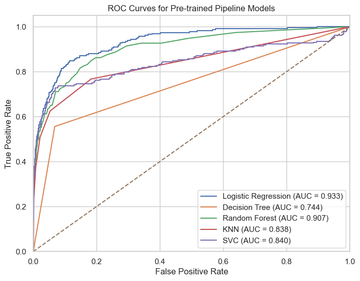

|  | Model | AUC | Hamming Loss |
| --- | --- | --- | --- |
| 0 | Logistic Regression | 0.932651 | 0.0660 |
| 1 | Random Forest | 0.906764 | 0.0705 |
| 2 | SVC | 0.840403 | 0.0700 |
| 3 | KNN | 0.838394 | 0.0760 |
| 4 | Decision Tree | 0.744081 | 0.1115 |

```python
# Import additional libraries
from sklearn.metrics import roc_curve, auc, hamming_loss

# Store the pre-trained fitted pipeline models in a dictionary
models = {
    "Logistic Regression": log_model,
    "Decision Tree": tree_model,
    "Random Forest": rf_model,
    "KNN": knn_model,
    "SVC": svm_model,
}

# Prepare containers for results
results = []

# Create ROC plot
plt.figure(figsize=(8, 6))

for model_name, model in models.items():
    # Predict class labels
    y_pred = model.predict(X_test)

    # Get score values for ROC/AUC
    if hasattr(model, "predict_proba"):
        y_score = model.predict_proba(X_test)[:, 1]
    elif hasattr(model, "decision_function"):
        y_score = model.decision_function(X_test)
    else:
        raise AttributeError(f"{model_name} does not support predict_proba or decision_function.")

    # Compute ROC curve and AUC
    fpr, tpr, _ = roc_curve(y_test, y_score)
    roc_auc = auc(fpr, tpr)

    # Compute Hamming loss
    ham_loss = hamming_loss(y_test, y_pred)

    # Save results
    results.append({
        "Model": model_name,
        "AUC": roc_auc,
        "Hamming Loss": ham_loss
    })

    # Plot ROC curve
    plt.plot(fpr, tpr, label=f"{model_name} (AUC = {roc_auc:.3f})")

# Add diagonal baseline
plt.plot([0, 1], [0, 1], linestyle="--")

# Format plot
plt.xlim([0.0, 1.0])
plt.ylim([0.0, 1.05])
plt.xlabel("False Positive Rate")
plt.ylabel("True Positive Rate")
plt.title("ROC Curves for Pre-trained Pipeline Models")
plt.legend(loc="lower right")
plt.grid(True)
plt.show()

# Create and display summary table
results_df = pd.DataFrame(results)
results_df = results_df.sort_values(by="AUC", ascending=False).reset_index(drop=True)
display(results_df)
```

## Randomized Search

Using RandomizedSearchCV from scikitlearn, we attempt to identify a reasonable combination of hyperparameters for each model tested above to determine if Logistic Regression is still the ideal choice for this dataset.

We recognize the marking rubric stipulates that hyperparameter tuning should be applied to the best performing model (in this case, Logistic Regression), however we elected to expand our exploration of the hyperparameter tuning analysis to assess how all of the models behave with tuning, to see if we can improve underperforming models, and identify whether a properly tuned model other than Logistic Regression might be a more optimal choice for this data set.

In the interest of adhering to the assignment deliverable, the Logistic Regression model's hyperparameter tuning is the first sequence we explore following this markdown, with the new accuracy included in the Hyperparameter analysis conducted by SciKitLearn. We then continue on with the tuning of each subsequent model in turn, with an additional comparison between the tuned models, as well as the revised ROC-AUC and Hamming loss for the tuned models. We finish with a final comparison of accuracy between the tuned and untuned models.

Using the same procedure as before, we use the existing pipelines that were constructed, adapting them to account for hyperparameter optimization.

```python
# Import additional libraries for tuning and parameter analysis
from sklearn.model_selection import RandomizedSearchCV
from scipy.stats import randint, loguniform
```

```python
# Import logistic regression classifier
from sklearn.linear_model import LogisticRegression

# Create a pipeline that combines the preprocessor with the logistic regression model
log_model = Pipeline([
    ("preprocess", preprocessor),
    ("model", LogisticRegression(max_iter=1000))
])

# specify which step the the hyperparameters belong to
log_param_dists = {
        "model__C": loguniform(0.01, 10)
}

# Create RandomizedSearchCV object for logistic regression, where n_iter sets the number
# of combinations of hyperparameters. 5-fold cross-validation achieved setting cv = 5
# optimize for accuracy (set scoring = 'accuracy)
# n_jobs = -1 use all available CPU cores
log_randomized_search = RandomizedSearchCV(
    estimator = log_model,
    param_distributions = log_param_dists,
    n_iter= 25,
    cv = 5,
    scoring = "accuracy",
    n_jobs = -1,
    random_state = 42
)

# Fit the randomized search to the training data to find the best hyperparameters
log_randomized_search.fit(X_train, y_train)

# Identify the best hyperparameters and best CV score from the randomized search results
print("Best Parameters:", log_randomized_search.best_params_)
print("Best CV Score (Accuracy):", log_randomized_search.best_score_)
print()

# Create a DataFrame from the randomized search results to examine the performance of
# different hyperparameter combinations
log_randomized_search_results = pd.DataFrame(log_randomized_search.cv_results_).loc[:,
    ["param_model__C", "mean_test_score", "std_test_score", "rank_test_score"]]
log_randomized_search_results.columns = ["C", "Mean Test Score", "Std Test Score", "Rank Test Score"]

print("CV Results for Logistic Regression:\n", log_randomized_search_results.sort_values("Mean Test Score", ascending = False))
print()

# Get the best model from the randomized search results
log_best_model = log_randomized_search.best_estimator_

# Make predictions on the test set
log_best_preds = log_best_model.predict(X_test)
print("Logistic Regression Accuracy on test set after Hyperparameter Tuning:", accuracy_score(y_test, log_best_preds))
```

```
Best Parameters: {'model__C': np.float64(0.08179499475211674)}
Best CV Score (Accuracy): 0.9345000000000001

CV Results for Logistic Regression:
            C  Mean Test Score  Std Test Score  Rank Test Score
16  0.081795         0.934500        0.004209                1
23  0.125628         0.934500        0.004077                2
18  0.197622         0.934375        0.003211                3
0   0.132929         0.934250        0.003631                4
1   7.114476         0.934250        0.003410                5
12  3.142881         0.934250        0.003410                5
7   3.967605         0.934250        0.003410                5
17  0.375206         0.934250        0.003387                5
11  8.123245         0.934250        0.003410                5
20  0.684792         0.934125        0.003414               10
```

[output cut: 17 more lines]

```python
# Import decision tree classifier
from sklearn.tree import DecisionTreeClassifier

# Create a pipeline that combines the preprocessor with the decision tree model
tree_model = Pipeline([
    ("preprocess", preprocessor),
    ("model", DecisionTreeClassifier(random_state=42))
])

# specify which step the the hyperparameters belong to
tree_param_dists = {
        "model__max_depth": randint(3, 20),
        "model__min_samples_split": randint(2, 10),
        "model__min_samples_leaf": randint(1, 5)
    }

# Create RandomizedSearchCV object for logistic regression, where n_iter sets the number
# of combinations of hyperparameters. 5-fold cross-validation achieved setting cv = 5
# optimize for accuracy (set scoring = 'accuracy)
# n_jobs = -1 use all available CPU cores
tree_randomized_search = RandomizedSearchCV(
    estimator = tree_model,
    param_distributions = tree_param_dists,
    n_iter= 25,
    cv = 5,
    scoring = "accuracy",
    n_jobs = -1,
    random_state = 42
)

# Fit the randomized search to the training data to find the best hyperparameters
tree_randomized_search.fit(X_train, y_train)

# Identify the best hyperparameters and best CV score from the randomized search results
print("Best Parameters:", tree_randomized_search.best_params_)
print("Best CV Score (Accuracy):", tree_randomized_search.best_score_)
print()

# Create a DataFrame from the randomized search results to examine the performance of
# different hyperparameter combinations
tree_randomized_search_results = pd.DataFrame(tree_randomized_search.cv_results_).loc[:,
    ["param_model__max_depth", "param_model__min_samples_split", "param_model__min_samples_leaf", "mean_test_score", "std_test_score", "rank_test_score"]]
tree_randomized_search_results.columns = ["Max Depth", "Min Samples Split", "Min Samples Leaf", "Mean Test Score", "Std Test Score", "Rank Test Score"]

print("CV Results for Decision Tree:\n", tree_randomized_search_results.sort_values("Mean Test Score", ascending = False))
print()

# Get the best model from the randomized search results
tree_best_model = tree_randomized_search.best_estimator_

# Make predictions on the test set
tree_best_preds = tree_best_model.predict(X_test)
print("Decision Tree Accuracy on test set after Hyperparameter Tuning:", accuracy_score(y_test, tree_best_preds))
```

```
Best Parameters: {'model__max_depth': 3, 'model__min_samples_leaf': 4, 'model__min_samples_split': 3}
Best CV Score (Accuracy): 0.933

CV Results for Decision Tree:
     Max Depth  Min Samples Split  Min Samples Leaf  Mean Test Score  \
8           3                  3                 4         0.933000
6           4                  5                 4         0.932250
19          4                  5                 4         0.932250
14          5                  4                 1         0.929625
5           5                  6                 2         0.929625
4           6                  9                 4         0.928750
7           8                  9                 2         0.925625
0           9                  6                 4         0.923375
2           9                  4                 2         0.923375
16          9                  5                 2         0.923000
```

[output cut: 44 more lines]

```python
# Import random forest classifier
from sklearn.ensemble import RandomForestClassifier

# Create a pipeline that combines the preprocessor with the random forest classifier model
rf_model = Pipeline([
    ("preprocess", preprocessor),
    ("model", RandomForestClassifier(random_state=42))
])

# specify which step the the hyperparameters belong to
rf_param_dists = {
        "model__n_estimators": randint(100, 600),
        "model__max_depth": randint(5, 20),
        "model__min_samples_split": randint(2, 10),
        "model__min_samples_leaf": randint(1, 5)
    }

# Create RandomizedSearchCV object for logistic regression, where n_iter sets the number
# of combinations of hyperparameters. 5-fold cross-validation achieved setting cv = 5
# optimize for accuracy (set scoring = 'accuracy)
# n_jobs = -1 use all available CPU cores
rf_randomized_search = RandomizedSearchCV(
    estimator = rf_model,
    param_distributions = rf_param_dists,
    n_iter= 25,
    cv = 5,
    scoring = "accuracy",
    n_jobs = -1,
    random_state = 42
)

# Fit the randomized search to the training data to find the best hyperparameters
rf_randomized_search.fit(X_train, y_train)

# Identify the best hyperparameters and best CV score from the randomized search results
print("Best Parameters:", rf_randomized_search.best_params_)
print("Best CV Score (Accuracy):", rf_randomized_search.best_score_)
print()

# Create a DataFrame from the randomized search results to examine the performance of
# different hyperparameter combinations
rf_randomized_search_results = pd.DataFrame(rf_randomized_search.cv_results_).loc[:,
    ["param_model__n_estimators", "param_model__max_depth", "param_model__min_samples_split", "param_model__min_samples_leaf", "mean_test_score", "std_test_score", "rank_test_score"]]
rf_randomized_search_results.columns = ["N Estimators", "Max Depth", "Min Samples Split", "Min Samples Leaf", "Mean Test Score", "Std Test Score", "Rank Test Score"]

print("CV Results for Random Forest:\n", rf_randomized_search_results.sort_values("Mean Test Score", ascending = False))
print()

# Get the best model from the randomized search results
rf_best_model = rf_randomized_search.best_estimator_

# Make predictions on the test set
rf_best_preds = rf_best_model.predict(X_test)
print("Random Forest Accuracy on test set after Hyperparameter Tuning:", accuracy_score(y_test, rf_best_preds))
```

```
Best Parameters: {'model__max_depth': 6, 'model__min_samples_leaf': 4, 'model__min_samples_split': 2, 'model__n_estimators': 415}
Best CV Score (Accuracy): 0.933

CV Results for Random Forest:
     N Estimators  Max Depth  Min Samples Split  Min Samples Leaf  \
16           415          6                  2                 4
22           101          6                  5                 4
4            230          8                  9                 4
24           290          8                  6                 2
0            370         11                  6                 4
21           519          7                  2                 2
1            120         15                  6                 4
11           289         16                  8                 4
12           150         18                  7                 3
3            472         15                  9                 3
```

[output cut: 44 more lines]

```python
# Import KNN classifier
from sklearn.neighbors import KNeighborsClassifier

# Create a pipeline that combines the preprocessor with the KNN model
knn_model = Pipeline([
    ("preprocess", preprocessor),
    ("model", KNeighborsClassifier())
])

# specify which step the the hyperparameters belong to
knn_param_dists = {
        "model__n_neighbors": randint(3, 20),
        "model__weights": ["uniform", "distance"]
    }

# Create RandomizedSearchCV object for logistic regression, where n_iter sets the number
# of combinations of hyperparameters. 5-fold cross-validation achieved setting cv = 5
# optimize for accuracy (set scoring = 'accuracy)
# n_jobs = -1 use all available CPU cores
knn_randomized_search = RandomizedSearchCV(
    estimator = knn_model,
    param_distributions = knn_param_dists,
    n_iter= 25,
    cv = 5,
    scoring = "accuracy",
    n_jobs = -1,
    random_state = 42
)

# Fit the randomized search to the training data to find the best hyperparameters
knn_randomized_search.fit(X_train, y_train)

# Identify the best hyperparameters and best CV score from the randomized search results
print("Best Parameters:", knn_randomized_search.best_params_)
print("Best CV Score (Accuracy):", knn_randomized_search.best_score_)
print()

# Create a DataFrame from the randomized search results to examine the performance of
# different hyperparameter combinations
knn_randomized_search_results = pd.DataFrame(knn_randomized_search.cv_results_).loc[:,
    ["param_model__n_neighbors", "param_model__weights", "mean_test_score", "std_test_score", "rank_test_score"]]
knn_randomized_search_results.columns = ["N Neighbors", "Weights", "Mean Test Score", "Std Test Score", "Rank Test Score"]

print("CV Results for KNN:\n", knn_randomized_search_results.sort_values("Mean Test Score", ascending = False))
print()

# Get the best model from the randomized search results
knn_best_model = knn_randomized_search.best_estimator_

# Make predictions on the test set
knn_best_preds = knn_best_model.predict(X_test)
print("KNN Accuracy on test set after Hyperparameter Tuning:", accuracy_score(y_test, knn_best_preds))
```

```
Best Parameters: {'model__n_neighbors': 17, 'model__weights': 'uniform'}
Best CV Score (Accuracy): 0.931

CV Results for KNN:
     N Neighbors   Weights  Mean Test Score  Std Test Score  Rank Test Score
1            17   uniform         0.931000        0.001920                1
21           16  distance         0.930750        0.001447                2
14           18   uniform         0.930500        0.002284                3
12           19   uniform         0.930375        0.001611                4
15           17  distance         0.930375        0.001510                4
24           17  distance         0.930375        0.001510                4
4            13   uniform         0.930250        0.001879                7
11           14   uniform         0.929000        0.003274                8
16           14   uniform         0.929000        0.003274                8
8            14  distance         0.928750        0.002016               10
```

[output cut: 17 more lines]

```python
# Import SVM classifier
from sklearn.svm import SVC

# Create a pipeline that combines the preprocessor with the SVM model
svm_model = Pipeline([
    ("preprocess", preprocessor),
    ("model", SVC())
])

# specify which step the the hyperparameters belong to
svm_param_dists = {
        "model__C": loguniform(0.1, 10),
        "model__kernel": ["linear", "rbf"],
        "model__gamma": ["scale", "auto"]
    }

# Create RandomizedSearchCV object for logistic regression, where n_iter sets the number
# of combinations of hyperparameters. 5-fold cross-validation achieved setting cv = 5
# optimize for accuracy (set scoring = 'accuracy)
# n_jobs = -1 use all available CPU cores
svm_randomized_search = RandomizedSearchCV(
    estimator = svm_model,
    param_distributions = svm_param_dists,
    n_iter= 25,
    cv = 5,
    scoring = "accuracy",
    n_jobs = -1,
    random_state = 42
)

# Fit the randomized search to the training data to find the best hyperparameters
svm_randomized_search.fit(X_train, y_train)

# Identify the best hyperparameters and best CV score from the randomized search results
print("Best Parameters:", svm_randomized_search.best_params_)
print("Best CV Score (Accuracy):", svm_randomized_search.best_score_)
print()

# Create a DataFrame from the randomized search results to examine the performance of different hyperparameter combinations
svm_randomized_search_results = pd.DataFrame(svm_randomized_search.cv_results_).loc[:,
    ["param_model__C", "param_model__kernel", "param_model__gamma", "mean_test_score", "std_test_score", "rank_test_score"]]
svm_randomized_search_results.columns = ["C", "Kernel", "Gamma", "Mean Test Score", "Std Test Score", "Rank Test Score"]

print("CV Results for SVM:\n", svm_randomized_search_results.sort_values("Mean Test Score", ascending = False))
print()

# Get the best model from the randomized search results
svm_best_model = svm_randomized_search.best_estimator_

# Make predictions on the test set
svm_best_preds = svm_best_model.predict(X_test)
print("SVM Accuracy on test set after Hyperparameter Tuning:", accuracy_score(y_test, svm_best_preds))
```

```
Best Parameters: {'model__C': np.float64(0.5611516415334505), 'model__gamma': 'scale', 'model__kernel': 'linear'}
Best CV Score (Accuracy): 0.9337500000000001

CV Results for SVM:
            C  Kernel  Gamma  Mean Test Score  Std Test Score  Rank Test Score
0   0.561152  linear  scale         0.933750        0.001896                1
1   2.910636  linear  scale         0.933750        0.001896                1
3   0.130667  linear   auto         0.933750        0.001896                1
4   1.593052  linear   auto         0.933750        0.001896                1
8   0.405961  linear   auto         0.933750        0.001896                1
14  1.530485  linear  scale         0.933750        0.001896                1
15  1.640929  linear  scale         0.933750        0.001896                1
11  0.383963  linear   auto         0.933750        0.001896                1
9   0.730954  linear  scale         0.933750        0.001896                1
21  0.117159  linear   auto         0.933750        0.001896                1
```

[output cut: 17 more lines]

```python
# Evaluate each 'best' model's performance on the test set following hyperparameter tuning
evaluate_model("Logistic Regression", y_test, log_best_preds)
evaluate_model("Decision Tree", y_test, tree_best_preds)
evaluate_model("Random Forest", y_test, rf_best_preds)
evaluate_model("KNN", y_test, knn_best_preds)
evaluate_model("SVM", y_test, svm_best_preds)
```

```
Model: Logistic Regression
Accuracy: 0.933
Confusion Matrix:
[[1740   28]
 [ 106  126]]
Classification Report:
              precision    recall  f1-score   support

           0       0.94      0.98      0.96      1768
           1       0.82      0.54      0.65       232

    accuracy                           0.93      2000
   macro avg       0.88      0.76      0.81      2000
weighted avg       0.93      0.93      0.93      2000



Model: Decision Tree
Accuracy: 0.931
Confusion Matrix:
[[1736   32]
 [ 106  126]]
Classification Report:
              precision    recall  f1-score   support

           0       0.94      0.98      0.96      1768
           1       0.80      0.54      0.65       232

    accuracy                           0.93      2000
   macro avg       0.87      0.76      0.80      2000
weighted avg       0.93      0.93      0.93      2000



Model: Random Forest
Accuracy: 0.9325
Confusion Matrix:
[[1740   28]
 [ 107  125]]
Classification Report:
```

[output cut: 27 more lines]

```

Model: SVM
Accuracy: 0.9265
Confusion Matrix:
[[1743   25]
 [ 122  110]]
Classification Report:
              precision    recall  f1-score   support

           0       0.93      0.99      0.96      1768
           1       0.81      0.47      0.60       232

    accuracy                           0.93      2000
   macro avg       0.87      0.73      0.78      2000
weighted avg       0.92      0.93      0.92      2000
```

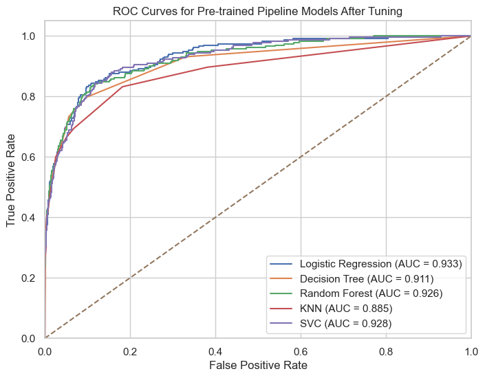

|  | Model | AUC | Hamming Loss |
| --- | --- | --- | --- |
| 0 | Logistic Regression | 0.932653 | 0.0670 |
| 1 | SVC | 0.927707 | 0.0735 |
| 2 | Random Forest | 0.926085 | 0.0675 |
| 3 | Decision Tree | 0.911137 | 0.0690 |
| 4 | KNN | 0.885381 | 0.0710 |

```python
# Import additional libraries
from sklearn.metrics import roc_curve, auc, hamming_loss

# Store the 'best-preds' pre-trained fitted pipeline models in a dictionary
models = {
    "Logistic Regression": log_best_model,
    "Decision Tree": tree_best_model,
    "Random Forest": rf_best_model,
    "KNN": knn_best_model,
    "SVC": svm_best_model,
}

# Prepare containers for results
results = []

# Create ROC plot
plt.figure(figsize=(8, 6))

for model_name, model in models.items():
    # Predict class labels
    y_pred = model.predict(X_test)

    # Get score values for ROC/AUC
    if hasattr(model, "predict_proba"):
        y_score = model.predict_proba(X_test)[:, 1]
    elif hasattr(model, "decision_function"):
        y_score = model.decision_function(X_test)
    else:
        raise AttributeError(f"{model_name} does not support predict_proba or decision_function.")

    # Compute ROC curve and AUC
    fpr, tpr, _ = roc_curve(y_test, y_score)
    roc_auc = auc(fpr, tpr)

    # Compute Hamming loss
    ham_loss = hamming_loss(y_test, y_pred)

    # Save results
    results.append({
        "Model": model_name,
        "AUC": roc_auc,
        "Hamming Loss": ham_loss
    })

    # Plot ROC curve
    plt.plot(fpr, tpr, label=f"{model_name} (AUC = {roc_auc:.3f})")

# Add diagonal baseline
plt.plot([0, 1], [0, 1], linestyle="--")

# Format plot
plt.xlim([0.0, 1.0])
plt.ylim([0.0, 1.05])
plt.xlabel("False Positive Rate")
plt.ylabel("True Positive Rate")
plt.title("ROC Curves for Pre-trained Pipeline Models After Tuning")
plt.legend(loc="lower right")
plt.grid(True)
plt.show()

# Create and display summary table
results_df = pd.DataFrame(results)
results_df = results_df.sort_values(by="AUC", ascending=False).reset_index(drop=True)
display(results_df)
```

```python
# Compare accuracy before and after hyperparameter tuning for each model
results = pd.DataFrame({
    "Model": ["Logistic Regression", "Decision Tree", "Random Forest", "KNN", "SVM"],
    "Accuracy Before Tuning": [accuracy_score(y_test, log_preds), accuracy_score(y_test, tree_preds), accuracy_score(y_test, rf_preds), accuracy_score(y_test, knn_preds), accuracy_score(y_test, svm_preds)],
    "Accuracy After Tuning": [accuracy_score(y_test, log_best_preds), accuracy_score(y_test, tree_best_preds), accuracy_score(y_test, rf_best_preds), accuracy_score(y_test, knn_best_preds), accuracy_score(y_test, svm_best_preds)]
})

print(results)
```

```
                 Model  Accuracy Before Tuning  Accuracy After Tuning
0  Logistic Regression                  0.9340                 0.9330
1        Decision Tree                  0.8885                 0.9310
2        Random Forest                  0.9295                 0.9325
3                  KNN                  0.9240                 0.9290
4                  SVM                  0.9300                 0.9265
```

# Results

Following the hyperparameter tuning, we note that Logistic Regression continues to be the most accurate model, though it did lose a small amount of accuracy, and the hamming loss went up slightly. SVM similarly performed about the same, with a slight decrease in accuracy and slightly more Hamming Loss compared to the un-tuned run. The other three models improved with hyperparameter tuning, with all models demonstrating similar accuracy in the range of ~93%.